# Week 15: End of Class Review

PS 818 - Statistical Models

Anton Strezhnev

strezhnev@wisc.edu

University of Wisconsin-Madison

December 8, 2025

# Quantitative Social Science and Political Science

$$\require{cancel}
\DeclareMathOperator*{\argmin}{arg\,min}$$

$$\DeclareMathOperator*{\argmax}{arg\,max}$$

# The Ideal Methods Sequence

- **Intro to Statistics**
  - Fundamentals of probability theory
  - Principles of statistical inference
  - Point/Interval Estimation; Hypothesis Testing
  - Where does **uncertainty** come from in the research process?
- **Causal Inference**
  - What is a causal effect?
  - What assumptions do we need to learn these from data?
  - What can we do when we can’t randomize?
- **Statistical Models**
  - What is a statistical model?
  - How do we estimate the **parameters** of the model?
  - How do we generate **predictions**?
  - How do we evaluate the quality of a predictive model?
  - How can we use models to **describe** and **summarize**

# My philosophy in a nutshell

1. The goal of statistics in science is to properly characterize error in the process of observation.
2. Models aren’t real.
3. Causal effects **are** real.
4. “Mechanisms” are either statements about mediation or interaction
5. Models are useful if they can predict or if they can summarize

# A Typology of Political Science “Quant”

- **Experimentalists**
  - Psychology-based experimentalists
  - Stats/econometrics-based experimentalists
- **Observational Causal Inference**
  - “Credibility revolution”
  - Model-based inference
- **Observational** (non-causal)
  - “Structural” estimation
  - Model-based description
- **Pure description**
  - Public opinion surveys

# A Typology of Political Science “Quant”

- Where does “text-as-data” fit in?
  - Some of this is just “advanced” methods to replace human coders (e.g. LLMs)
  - But the actual **models** usually fall into “model-based description”
- How about the formal modellers?
  - No empirics/motivating qualitative case (IMO, ideal)
  - Structural estimation of model parameters.
  - “Hypotheses” obtained from comparative statics on model parameters $\leadsto$ standard causal inference
- Some will argue that empirics are useless without a connection to some feature of a theoretical model.
  - I’d disagree - causal effects are still “real” insofar as they correspond to an intervention we could do
  - I will grant that any sort of notion of generalization/transportation needs a theory

# This course

1. Linear regression to estimate $E[Y|X]$ using a linear combination of the columns of $X$
2. Generalized Linear Models to estimate $E[Y|X]$ using a linear combination of the columns of $X$ and a **transformation** $g()$
3. Maximum Likelihood to obtain CAN estimates of GLM parameters
4. Bayesian inference on parameters - **posterior** = **likelihood** $\times$ **prior**
5. Bayesian inference for GLMs - Incorporating structure through priors
6. Models for summarizing data: mixture models, factor models
7. Models for flexibly estimating $E[Y|X]$

# What we didn’t cover

- Method of moments estimation (common in econometrics/structural estimation).
  - **General concept**: Estimators as *solutions to systems of equations* - you saw this with MLE (we set the score to 0)
- Neural networks
  - Defining input-output models via sequences of **layers**
  - Lots of “reinvention” of concepts from stats (with different names)
  - Building blocks look like familiar models we’ve seen (e.g. logistic regression)

# Review: OLS

- A **linear predictor** is defined as a linear combination of the explanatory variables and coefficients

  $$m(x) = x^\prime\beta = \beta_0 + \beta_1 x_1 + \beta_2 x_2 + \beta_3 x_3 + \dotsc$$
- The **best linear predictor** is the linear predictor that minimizes the **population** squared prediction error

  $$\beta = \argmin_b \ \mathbb{E}[(Y_i - X_i^\prime b)^2]$$
- There’s a closed form solution in terms of population expectations.

  $$m(X_i) = X_i^\prime\beta = X_i^\prime (\mathbb{E}[X_iX_i^\prime])^{-1}\mathbb{E}[X_iY_i]$$

# Review: OLS

- **Ordinary Least Squares** is an estimator applied to paired observations $Y_i$, and $X_i$

  $$\hat{\beta} = \bigg(\frac{1}{n} \sum_{i=1}^n X_iX_i^\prime\bigg)^{-1}\bigg(\frac{1}{n} \sum_{i=1}^n X_iY_i\bigg)$$
- Often written as:

  $$\hat{\beta} = (\mathbf{X}^\prime\mathbf{X})^{-1}(\mathbf{X}^\prime Y)$$
- When is this consistent for the BLP?
  - When we have a sample from the target population (however you define the population)
  - And no perfect collinearity

# Review: OLS

- To do inference on the CEF, we assume that it’s equal to the BLP!
- **Assumption 1**: Linearity

  $$Y_i = X_i^\prime\beta + \epsilon_i$$
- **Assumption 2**: Strict exogeneity of the errors

  $$\mathbb{E}[\epsilon | \mathbf{X}] = 0$$
- What does this get us?
  - Finite-sample properties of OLS (unbiasedness in addition to consistency!)
- When is linearity always **true**?
  - When we have a fully-saturated model!

# Review: OLS

- To do inference on the CEF, we assume that it’s equal to the BLP!
- **Assumption 1**: Linearity

  $$Y_i = X_i^\prime\beta + \epsilon_i$$
- **Assumption 2**: Strict exogeneity of the errors

  $$\mathbb{E}[\epsilon | \mathbf{X}] = 0$$
- What does this get us?
  - Finite-sample properties of OLS (unbiasedness in addition to consistency!)
- When is linearity always **true**?
  - When we have a fully-saturated model!

# Review: OLS

- With no other assumptions, inference on the sampling variance of $\hat{\beta}$ takes the form of the “sandwich estimator”

  $$\widehat{Var(\hat{\beta})} = (\mathbf{X}^\prime\mathbf{X})^{-1} (X^\prime \hat{\Sigma} \mathbf{X}) (\mathbf{X}^\prime\mathbf{X})^{-1}$$
- Under i.i.d. but heteroskedastic observations, we’ll plug in $\hat{\Sigma} = \text{diag}(\hat{e_1}^2, \hat{e_2}^2, \dotsc \hat{e_n}^2)$
  - “Heteroskedasticity-robust” SEs (HC1, HC2, HC3, etc…)
- If we assume arbitrary correlation across observations **within** cluster but independence **across** clusters, our plug-in for $\hat{\Sigma}$ is a block diagonal matrix with off-diagonals $\hat{e_i}\hat{e_j}$ for $i, j$ in the same cluster.
  - “Clustered standard errors”

# Some useful-to-remember OLS tricks

- Sum of the OLS residuals is zero

  $$\sum_{i=1}^N (Y_i - \hat{Y_i}) = 0$$
- We can go from $Y$ to $\hat{Y}$ via the **projection matrix**

  $$\mathbf{P}_{\mathbf{X}} = \mathbf{X}(\mathbf{X}^\prime\mathbf{X})^{-1}\mathbf{X^\prime}$$
- **Frisch-Waugh-Lovell** - Any OLS coefficient $\hat{\beta}_k$ can be written as

  $$\hat{\beta}_k = \frac{\widehat{\text{Cov}}(Y^{\perp \mathbb{X}_{-k}}, X_k^{\perp \mathbb{X}_{-k}})}{\widehat{\text{Var}}( X_k^{\perp \mathbb{X}_{-k}}) }$$

# Generalized Linear Models

- When teaching OLS, we focused on estimating the CEF $E[Y|X]$ with linear regression
  - The CEF is an “optimal predictor” for $Y$ in that it achieves lowest mean-squared error.
- We want to make predictions for **out of sample** observations
  - Covariate profiles that don’t necessarily exist in our sample.
- Our linear CEF assumption might create some problems!
  - With a binary outcome, we might get predictions that are negative or greater than 1 - **impossible probabilities**
- GLMs model a **function** of the CEF with the linear predictor

  $$g(E[Y|X]) = X\beta$$

# The logistic regression

# Logistic regression

- The “logit” or “logistic” GLM models the **log-odds** of a binary outcome as a function of the linear predictor $X_i^{\prime}\beta$

  $$Y_i \underset{\text{i.i.d}}{\sim} \text{Bernoulli}(\pi_i)$$

  $$E[Y_i | X_i] = Pr(Y_i = 1 | X_i) = \pi_i$$

  $$\log\bigg(\frac{\pi_i}{1-\pi_i}\bigg) = X_i^{\prime}\beta$$
- Alternatively, this is written in terms of the “inverse-link” function (the logistic function) that relates $\pi_i$ to $g^{-1}(X_i^{\prime}\beta)$

  $$\pi_i = \frac{\exp(X_i^{\prime}\beta)}{1 + \exp(X_i^{\prime}\beta)} = \frac{1}{1 + \exp(-X_i^{\prime}\beta)}$$

# Maximum Likelihood

- We obtain an estimate of $\beta$, $\hat{\beta}$ using maximum likelihood.
- Our MLE estimator maximizes the **likelihood** conditional on the data

  $$\hat{\beta} = \argmax_\beta \ \log f(\mathbf{y} | \beta, \mathbf{X})$$
- This likelihood is defined as the density of the data
  - But don’t confuse it with a density as the input is the **parameter value** and not the **data** itself
- Optimization via **numerical techniques**
  - Newton-Raphson
  - Gradient Ascent

# Example: Propensity Scores

- Let’s go back to the **Keriakes et. al. (2000)** dataset and play around a bit more with the model structure

```r
# Read in the dataset
pci <- read_csv("data/pci.csv")
```

- We want to predict treatment: `abcix` using a mix of discrete and continuous covariates…
  - `stent` - Coronary stent deployment; binary indicator
  - `height` - Height in centimeters; numeric integer
  - `female` - Female gender; binary indicator
  - `diabetic` - Diabetes mellitus diagnosis; binary indicator
  - `acutemi` - Acute myocardial infarction within the previous 7 days; binary indicator
  - `ejecfrac` - Left ejection fraction; numeric integer
  - `ves1proc` - Number of vessels involved in the patient’s initial PCI procedure; numeric integer

# Example: Propensity Scores

- First, let’s just illustrate why OLS is going to not work well for the task of obtaining **fitted values** when we don’t have a saturated model.

```r
ols_reg <- lm(abcix ~ stent*(female + height + diabetic + acutemi + ejecfrac + ves1proc), data=pci)
pci$ols_fitted <- predict(ols_reg)
```

# Example: Propensity Scores

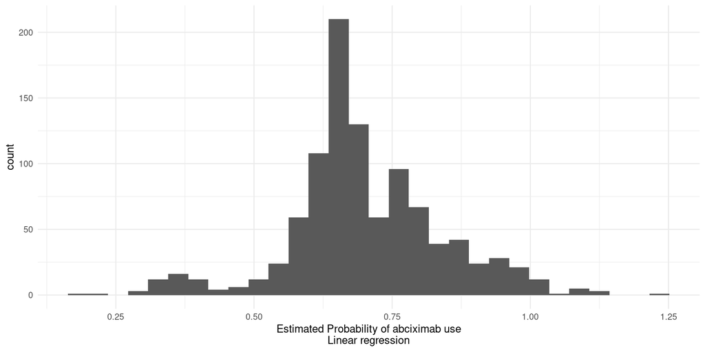

# Example: Propensity Scores

- Let’s fit the logistic regression

```r
pscore_reg <- glm(abcix ~ stent*(female + height + diabetic + acutemi + ejecfrac + ves1proc), data=pci,
                  family=binomial(link="logit"))
pci$prob_treat <- predict(pscore_reg, type="response")
```

# Example: Propensity Scores

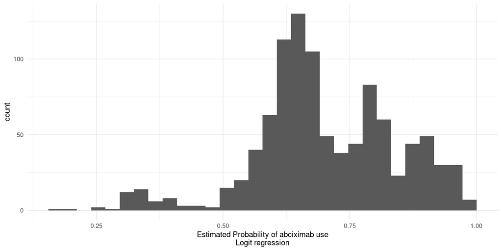

# Validating binary classifiers

- We can compute the classic measures of “error” that we’re used to (e.g. in-sample or out-of-sample mean squared error).
- But binary classifiers are often visualized using **Receiver Operating Characteristic** (ROC) curves.
- The logistic regression outputs a **continuous** estimate of $Pr(Y = 1 | X)$
  - But converting that to an actual 0/1 **prediction** requires setting some threshold probability.
- If we set the threshold low, that guarantees we’ll get every **true positive**
  - But we’ll get a lot of **false postiives** too
- The **ROC** curve captures this trade-off. Different points reflect different classification thresholds
  - **x-axis** - false positive rate
  - **y-axis** - true positive rate

# ROC Curve

- A recent implementation of this exists in the `plotROC` R package

```r
library(plotROC)
in_sample_roc <- pci %>% ggplot(aes(d = abcix, m = prob_treat)) + geom_roc() + theme_minimal() +
  labs(x = "False Positive Rate", y = "True Positive Rate") + geom_abline(lty=2, col="indianred")
```

# ROC Curve

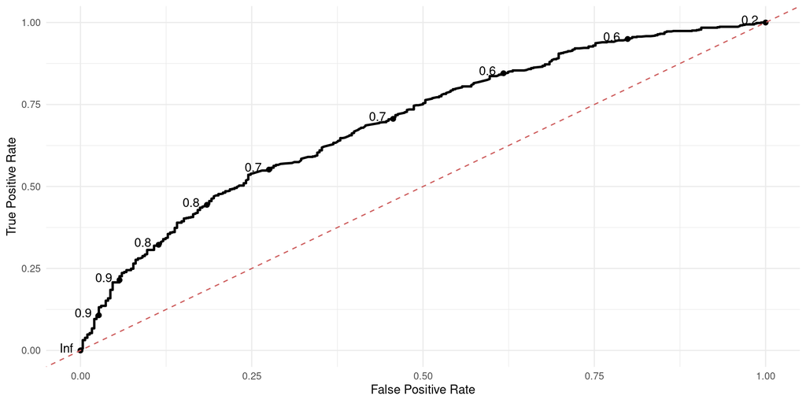

# ROC Curve

- What does a **purely random** classifier look like?

```r
set.seed(537)
pci$random_class <- runif(nrow(pci))
random_roc <- pci %>% ggplot(aes(d = abcix, m = random_class)) + geom_roc() + theme_minimal() +
  labs(x = "False Positive Rate", y = "True Positive Rate") + geom_abline(lty=2, col="indianred")
```

# ROC Curve

- It’s the 45 degree line!

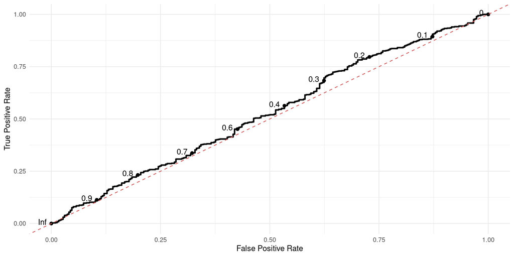

# ROC Curve

- What does a **perfect** classifier look like?

```r
true_roc <- pci %>% ggplot(aes(d = abcix, m = abcix)) + geom_roc() + theme_minimal() +
  labs(x = "False Positive Rate", y = "True Positive Rate") + geom_abline(lty=2, col="indianred")
```

# ROC Curve

- It’s the “box”

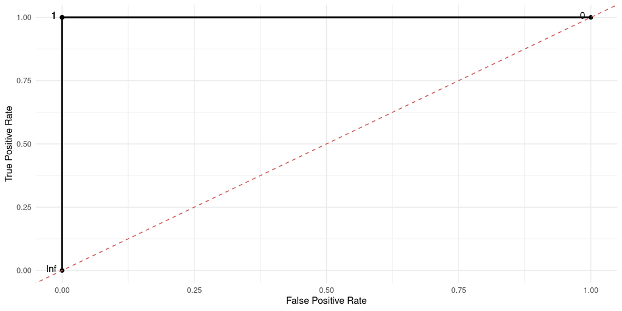

# ROC Curve

- A predictive model’s ROC curve will typically be between those two extremes
  - A common single-variable summary of predictive quality is therefore the **area under curve** (AUC)
- What’s the AUC of our model in-sample?

```r
calc_auc(in_sample_roc)
```

```
  PANEL group   AUC
1     1    -1 0.695
```

# Cross-validation

- We usually don’t want to focus too much on **in-sample** fit
  - A more flexible model will always improve in-sample fit (overfitting)
- Let’s implement a 5-fold cross-validation approach

```r
set.seed(537)
pci_shuffled <- pci[sample(1:nrow(pci)),]
pci_shuffled$fold <- cut(seq(1:nrow(pci)), breaks = 5, labels = FALSE)
pci_shuffled$prob_treat_cv <- NA
for (f in 1:5){
  pscore_reg_fold <- glm(abcix ~ stent*(female + height + diabetic + acutemi + ejecfrac + ves1proc), data=pci_shuffled %>% filter(fold != f),
                  family=binomial(link="logit"))
  pci_shuffled$prob_treat_cv[pci_shuffled$fold == f] <- predict(pscore_reg_fold, newdata = pci_shuffled %>% filter(fold == f), type="response")
}
```

# Cross-validation

```r
oos_roc <- pci_shuffled %>% ggplot(aes(d = abcix, m = prob_treat)) + geom_roc() + geom_roc(aes(m = prob_treat_cv), col="dodgerblue") + theme_minimal() +
  labs(x = "False Positive Rate", y = "True Positive Rate") + geom_abline(lty=2, col="indianred")
```

# Cross-validation

```r
oos_roc
```

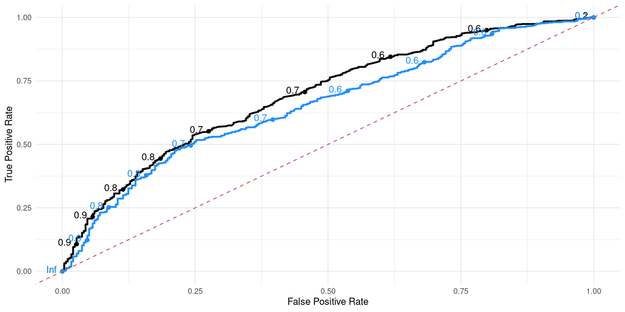

# More on hierarchical models

- In the Bayesian GLM, we introduced the idea of **regularizing** group-specific intercepts and slopes
  - Common “grand mean” intercept $\beta_0$
  - State-level **random effects** $\alpha_i \sim \text{Normal}(0, \sigma^2_{\alpha})$
- We estimate $\sigma^2_{\alpha}$ from the data (put an additional prior on it)
  - But could imagine fixing it to a particular value (as we did for the penalty in ridge regression)
  - High $\sigma^2_{\alpha}$ = less pooling
  - Low $\sigma^2_{\alpha}$ = more pooling

# Hierarchical Models

# More on regularization

- Here, we’re going to use the 2020 CES to study attitudes towards Trump’s trade policy

```r
ces <- read_csv("data/CES20_Common_OUTPUT_vv.csv")
```

# More on regularization

- We’re going to fit a model to see what predicts support for Trump’s tariff policy using `brms`

```r
library(brms)
```

- Estimate the model with just a regularizing prior on the coefficients (ridge regression)

```r
tariff_support <- brm(tariff ~ gender_bin + race_bin + age_bin + educ_bin,
                           family = bernoulli(), data=ces_full,
                      prior = set_prior("normal(0, 3)"),
                 cores=4, warmup=1000, iter=2000, seed=53703)
```

# More on regularization

```
 Family: bernoulli
  Links: mu = logit
Formula: tariff ~ gender_bin + race_bin + age_bin + educ_bin
   Data: ces_full (Number of observations: 60426)
  Draws: 4 chains, each with iter = 2000; warmup = 1000; thin = 1;
         total post-warmup draws = 4000

Regression Coefficients:
                      Estimate Est.Error l-95% CI u-95% CI Rhat Bulk_ESS
Intercept                 0.24      0.03     0.19     0.29 1.00     3718
gender_binFemale         -0.01      0.02    -0.04     0.03 1.00     7547
race_binAsian            -0.09      0.05    -0.19     0.00 1.00     6878
race_binBlack            -0.24      0.03    -0.29    -0.19 1.00     8583
race_binHispanic         -0.02      0.03    -0.07     0.03 1.00     7726
race_binOther             0.17      0.04     0.08     0.26 1.00     8518
age_bin30M44              0.19      0.03     0.14     0.24 1.00     3799
age_bin45M64              0.57      0.02     0.52     0.61 1.00     3504
age_bin65P                0.79      0.03     0.73     0.84 1.00     3748
educ_binCollegedegree    -0.40      0.02    -0.44    -0.35 1.00     4531
educ_binPostgraduate     -0.80      0.03    -0.85    -0.75 1.00     5604
educ_binSomecollege      -0.10      0.02    -0.14    -0.06 1.00     4466
                      Tail_ESS
Intercept                 3194
gender_binFemale          2687
race_binAsian             3214
race_binBlack             3393
race_binHispanic          3069
race_binOther             3032
age_bin30M44              3344
age_bin45M64              3268
age_bin65P                3596
educ_binCollegedegree     3721
educ_binPostgraduate      3639
educ_binSomecollege       3209

Draws were sampled using sampling(NUTS). For each parameter, Bulk_ESS
and Tail_ESS are effective sample size measures, and Rhat is the potential
scale reduction factor on split chains (at convergence, Rhat = 1).
```

# More on regularization

- What does the default “dummy” coding look like vs. “effect coding”

```r
contrasts(ces_full$educ_bin)
```

```
               College degree Postgraduate Some college
H.S. or less                0            0            0
College degree              1            0            0
Postgraduate                0            1            0
Some college                0            0            1
```

```r
contrasts(ces_full$educ_bin) <- contr.sum(levels(ces_full$educ_bin))
colnames(contrasts(ces_full$educ_bin)) <- rownames(contrasts(ces_full$educ_bin))[-nlevels(ces_full$educ_bin)]
contrasts(ces_full$educ_bin)
```

```
               H.S. or less College degree Postgraduate
H.S. or less              1              0            0
College degree            0              1            0
Postgraduate              0              0            1
Some college             -1             -1           -1
```

# More on regularization

- Let’s do this for gender, age and race

```r
contrasts(ces_full$gender_bin) <- contr.sum(levels(ces_full$gender_bin))
colnames(contrasts(ces_full$gender_bin)) <- rownames(contrasts(ces_full$gender_bin))[-nlevels(ces_full$gender_bin)]
contrasts(ces_full$age_bin) <- contr.sum(levels(ces_full$age_bin))
colnames(contrasts(ces_full$age_bin)) <- rownames(contrasts(ces_full$age_bin))[-nlevels(ces_full$age_bin)]
contrasts(ces_full$race_bin) <- contr.sum(levels(ces_full$race_bin))
colnames(contrasts(ces_full$race_bin)) <- rownames(contrasts(ces_full$race_bin))[-nlevels(ces_full$race_bin)]
```

# More on pooling

- Let’s re-fit the model and see what the coefficients look like?

```r
tariff_support2 <- brm(tariff ~ gender_bin + age_bin + race_bin + educ_bin,
                           family = bernoulli(), data=ces_full,
                      prior = set_prior("normal(0, 3)"),
                 cores=4, warmup=1000, iter=2000)
```

# More on regularization

```r
summary(tariff_support2)
```

```
 Family: bernoulli
  Links: mu = logit
Formula: tariff ~ gender_bin + age_bin + race_bin + educ_bin
   Data: ces_full (Number of observations: 60426)
  Draws: 4 chains, each with iter = 2000; warmup = 1000; thin = 1;
         total post-warmup draws = 4000

Regression Coefficients:
                      Estimate Est.Error l-95% CI u-95% CI Rhat Bulk_ESS
Intercept                 0.26      0.02     0.23     0.29 1.00     4150
gender_binMale            0.00      0.01    -0.01     0.02 1.00     6291
age_bin18M29             -0.39      0.02    -0.42    -0.36 1.00     4201
age_bin30M44             -0.19      0.01    -0.22    -0.17 1.00     4156
age_bin45M64              0.18      0.01     0.15     0.21 1.00     3657
race_binWhite             0.04      0.02     0.00     0.07 1.00     3933
race_binAsian            -0.06      0.04    -0.14     0.02 1.00     3021
race_binBlack            -0.20      0.02    -0.25    -0.15 1.00     3836
race_binHispanic          0.02      0.02    -0.03     0.06 1.00     4214
educ_binH.S.orless        0.32      0.01     0.30     0.35 1.00     4257
educ_binCollegedegree    -0.07      0.02    -0.10    -0.04 1.00     4191
educ_binPostgraduate     -0.47      0.02    -0.51    -0.44 1.00     3718
                      Tail_ESS
Intercept                 3120
gender_binMale            3255
age_bin18M29              3033
age_bin30M44              2927
age_bin45M64              3043
race_binWhite             2945
race_binAsian             3195
race_binBlack             3034
race_binHispanic          3318
educ_binH.S.orless        3377
educ_binCollegedegree     3482
educ_binPostgraduate      3330

Draws were sampled using sampling(NUTS). For each parameter, Bulk_ESS
and Tail_ESS are effective sample size measures, and Rhat is the potential
scale reduction factor on split chains (at convergence, Rhat = 1).
```

# More on regularization

- Why would we do this?
  - To allow us to **regularize the interactions** while keeping the **main effect parameters** still interpretable!
- Consider the following simple model

```r
summary(lm_robust(tariff ~ educ_bin, data=ces_full))
```

```
Call:
lm_robust(formula = tariff ~ educ_bin, data = ces_full)

Standard error type:  HC2

Coefficients:
                       Estimate Std. Error t value  Pr(>|t|) CI Lower CI Upper
(Intercept)              0.5728    0.00212  269.86  0.00e+00   0.5686   0.5769
educ_binH.S. or less     0.0749    0.00327   22.90 1.49e-115   0.0685   0.0813
educ_binCollege degree  -0.0224    0.00365   -6.12  9.37e-10  -0.0295  -0.0152
educ_binPostgraduate    -0.1008    0.00442  -22.79 1.66e-114  -0.1094  -0.0921
                          DF
(Intercept)            60422
educ_binH.S. or less   60422
educ_binCollege degree 60422
educ_binPostgraduate   60422

Multiple R-squared:  0.0149 ,   Adjusted R-squared:  0.0148
F-statistic:  299 on 3 and 60422 DF,  p-value: <2e-16
```

# More on regularization

- The coefficients on the main terms **are still marginal effects** when I put in the interaction with gender because I effect-coded

```r
summary(lm_robust(tariff ~ educ_bin*gender_bin, data=ces_full))
```

```
Call:
lm_robust(formula = tariff ~ educ_bin * gender_bin, data = ces_full)

Standard error type:  HC2

Coefficients:
                                      Estimate Std. Error t value  Pr(>|t|)
(Intercept)                            0.57519    0.00214  268.99  0.00e+00
educ_binH.S. or less                   0.08025    0.00334   24.02 6.63e-127
educ_binCollege degree                -0.02528    0.00366   -6.90  5.33e-12
educ_binPostgraduate                  -0.10299    0.00443  -23.26 3.83e-119
gender_binMale                         0.00379    0.00214    1.77  7.64e-02
educ_binH.S. or less:gender_binMale    0.02315    0.00334    6.93  4.23e-12
educ_binCollege degree:gender_binMale -0.01321    0.00366   -3.60  3.13e-04
educ_binPostgraduate:gender_binMale   -0.01997    0.00443   -4.51  6.48e-06
                                       CI Lower CI Upper    DF
(Intercept)                            0.571000  0.57938 60418
educ_binH.S. or less                   0.073704  0.08680 60418
educ_binCollege degree                -0.032461 -0.01810 60418
educ_binPostgraduate                  -0.111668 -0.09431 60418
gender_binMale                        -0.000402  0.00798 60418
educ_binH.S. or less:gender_binMale    0.016606  0.02970 60418
educ_binCollege degree:gender_binMale -0.020393 -0.00603 60418
educ_binPostgraduate:gender_binMale   -0.028650 -0.01129 60418

Multiple R-squared:  0.0162 ,   Adjusted R-squared:  0.0161
F-statistic:  142 on 7 and 60418 DF,  p-value: <2e-16
```

# More on regularization

- Let’s estimate the Bayesian GLM with no strong regularization on the interactions between age-gender-education.

```r
tariff_support3 <- brm(tariff ~ gender_bin + age_bin + race_bin + educ_bin + age_bin*educ_bin*gender_bin ,
                           family = bernoulli(), data=ces_full,
                      prior = set_prior("normal(0, 3)"),
                 cores=4, warmup=1000, iter=2000)
```

# More on regularization

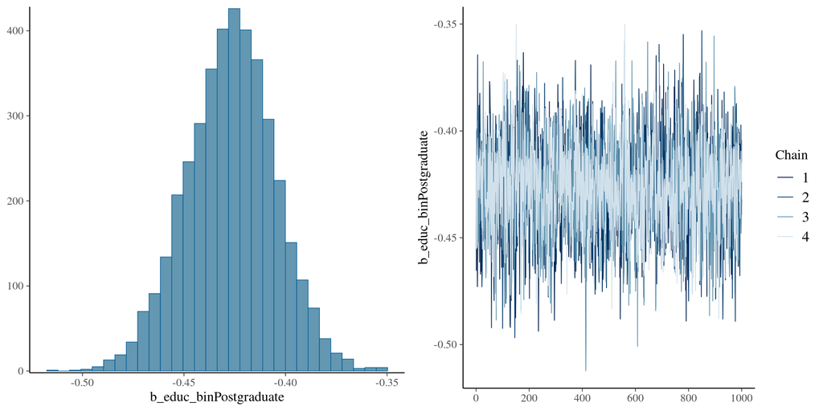

# More on regularization

- Now let’s regularize the higher-order interactions a lot more than the base coefficients

```r
interactions_prior <- get_prior(tariff_support3)
interactions_prior$prior[grep(":", interactions_prior$coef)] <- "normal(0, .0002)"
```

# More on regularization

```r
tariff_support4 <- brm(tariff ~ gender_bin + age_bin + race_bin + educ_bin + age_bin*educ_bin*gender_bin ,
                           family = bernoulli(), data=ces_full,
                      prior = interactions_prior,
                 cores=4, warmup=1000, iter=2000)
```

# More on regularization

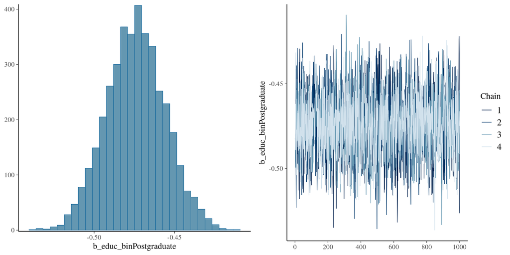